# STA6235 - Project 2 Assignment

Gabriel Rivera Alvarez

2022-08-10

## Libraries Used

```r
# Libraries to be used
library(tidyverse)
library(car)
```

## Dataset Reading

```r
# Load dataset
data <- read.csv("/Users/gabrielrivera/Documents/Maestria/Courses/4- Summer 2022/STA6235/Project 2/Walmart_Store_sales.csv")
```

## Dataset Display

```r
#Display first 5 rows of the dataset
head(data,5)
```

```
##   Store       Date Weekly_Sales Holiday_Flag Temperature Fuel_Price      CPI
## 1     1 05-02-2010      1643691            0       42.31      2.572 211.0964
## 2     1 12-02-2010      1641957            1       38.51      2.548 211.2422
## 3     1 19-02-2010      1611968            0       39.93      2.514 211.2891
## 4     1 26-02-2010      1409728            0       46.63      2.561 211.3196
## 5     1 05-03-2010      1554807            0       46.50      2.625 211.3501
##   Unemployment
## 1        8.106
## 2        8.106
## 3        8.106
## 4        8.106
## 5        8.106
```

## Dataset Description

As stated in Project 1, the dataset being used comes from Kaggle. The link to the dataset is: https://www.kaggle.com/datasets/rutuspatel/walmart-dataset-retail. This dataset contains columns that are: Store, Date, Weekly_Sales, Holiday_Flag, Temperature, Fuel_Price, CPI, and Unemployment. This dataset contains one categorical predictor, which is Holiday_Flag. This will be one of my categorical variables. Since the dataset does not contain another categorical predictor, I will filter the dataset to contain only stores 1 and 2. A categorical predictor will be generated to have Store 1 as 0 and Store 2 as 1. For the continuous predictors, I will be using Temperature and Fuel Price. The combination of this 4 variables will be used to determine a model to see if they are good predictors for the outcome of Weekly Sales.

## Dataset Filtering

```r
# Remove all the rows that do not belong to Store 1 or Store 2
data <- filter(data, Store <=2)
```

## Addition of Categorical Variable Based on Store

```r
# Add Column for categorical variable based on store. Put 0 if store 1 and put 1 if store 2
data$Store_No <- if_else(data$Store == 1, as.integer(0), as.integer(1))
```

## Dataset Extraction and Display

```r
# Put variables of interest as a tibble
dataset <- tibble(WkSales = data$Weekly_Sales, Temp = data$Temperature, Fuel_Price = data$Fuel_Price, Holiday = data$Holiday_Flag, Store_No = data$Store_No)
head(dataset,5)
```

```
## # A tibble: 5 × 5
##    WkSales  Temp Fuel_Price Holiday Store_No
##      <dbl> <dbl>      <dbl>   <int>    <int>
## 1 1643691.  42.3       2.57       0        0
## 2 1641957.  38.5       2.55       1        0
## 3 1611968.  39.9       2.51       0        0
## 4 1409728.  46.6       2.56       0        0
## 5 1554807.  46.5       2.62       0        0
```

## Statistical Summary

```r
# Statistics summary
summarize(dataset, mean_WkSales    = mean(dataset$WkSales, na.rm=TRUE),    sd_WkSales =sd(dataset$WkSales, na.rm=TRUE),
                   mean_Temp       = mean(dataset$Temp, na.rm=TRUE),       sd_Temp =sd(dataset$Temp, na.rm=TRUE),
                   mean_Fuel_Price = mean(dataset$Fuel_Price, na.rm=TRUE), sd_Fuel_Price =sd(dataset$Fuel_Price, na.rm=TRUE))
```

```
## # A tibble: 1 × 6
##   mean_WkSales sd_WkSales mean_Temp sd_Temp mean_Fuel_Price sd_Fuel_Price
##          <dbl>      <dbl>     <dbl>   <dbl>           <dbl>         <dbl>
## 1     1740508.    273323.      68.3    14.9            3.22         0.427
```

Doing a statistical summary we get an average Weekly Sales of $1,740,508 with a standard deviation of 273,323.1. For Temperature we have an average of 68.26157 degrees with a standard deviation of 14.85853. For Fuel Price we have an average of 3.219699 with a standard deviation of 0.4265622. Mean and standard deviation is not computed for Holiday and Store Number because they are categorical variables with either 0’s or 1’s. They are not continuous and there’s no meaning in computing an average or a standard deviation.

## Multiple Linear Regression Model

```r
m1 <- lm(WkSales ~ Temp + Fuel_Price + Holiday + Store_No + Holiday:Store_No, data = dataset)
summary(m1)
```

```
##
## Call:
## lm(formula = WkSales ~ Temp + Fuel_Price + Holiday + Store_No +
##     Holiday:Store_No, data = dataset)
##
## Residuals:
##     Min      1Q  Median      3Q     Max
## -361884  -89920  -23271   64283 1459638
##
## Coefficients:
##                   Estimate Std. Error t value Pr(>|t|)
## (Intercept)      1776570.8    96116.2  18.484  < 2e-16 ***
## Temp               -3223.6      802.6  -4.016  7.6e-05 ***
## Fuel_Price         -2137.9    27519.7  -0.078    0.938
## Holiday            82487.1    64010.5   1.289    0.199
## Store_No          367050.3    23699.6  15.488  < 2e-16 ***
## Holiday:Store_No   44976.5    89621.1   0.502    0.616
## ---
## Signif. codes:  0 '***' 0.001 '**' 0.01 '*' 0.05 '.' 0.1 ' ' 1
##
## Residual standard error: 193300 on 280 degrees of freedom
## Multiple R-squared:  0.5088, Adjusted R-squared:    0.5
## F-statistic: 58.01 on 5 and 280 DF,  p-value: < 2.2e-16
```

## Intercept and Slope Extraction for Full Model

```r
lin_coeff <- coefficients(m1)
lin_coeff
```

```
##      (Intercept)             Temp       Fuel_Price          Holiday
##      1776570.821        -3223.566        -2137.889        82487.144
##         Store_No Holiday:Store_No
##       367050.256        44976.477
```

## Resulting Multiple Linear Regression Model is:

$$\hat{WkSales} = 1.7765708\times 10^{6}
+ -3223.57*Temp + -2137.89*FuelPrice + 8.248714\times 10^{4}*Holiday +
3.6705026\times 10^{5}*StoreNo + 44976.5*Holiday:StoreNo$$

## Testing if the Interaction Between Holiday and Store Number is a Significant Predictor

```r
full <- m1
reduced <- m1 <- lm(WkSales ~ Temp + Fuel_Price + Holiday + Store_No, data = dataset)
anova(reduced,full)
```

```
## Analysis of Variance Table
##
## Model 1: WkSales ~ Temp + Fuel_Price + Holiday + Store_No
## Model 2: WkSales ~ Temp + Fuel_Price + Holiday + Store_No + Holiday:Store_No
##   Res.Df        RSS Df Sum of Sq      F Pr(>F)
## 1    281 1.0468e+13
## 2    280 1.0458e+13  1 9.407e+09 0.2519 0.6162
```

##### Hypotheses

- $H_0: \ \beta_{\text{Hol_Sto}} = 0$
- $H_1: \ \beta_{\text{Hol_Sto}} \ne 0$

##### Test Statistics

- $F_0 = 0.2519$
- $p$-Value $= 0.6162$

##### Rejection Region

- Reject $H_0$ if $p$-Value $< \alpha$; $\alpha = 0.05$

##### Conclusion and Interpretation

- FTR $H_0$. There is not sufficient evidence to suggest that the interaction between Holiday and Store Number is a significant predictor of Weekly Sales.

```r
full <- m1
reduced <- lm(WkSales ~ Holiday + Store_No + Holiday:Store_No, data = dataset)
anova(reduced,full)
```

```
## Analysis of Variance Table
##
## Model 1: WkSales ~ Holiday + Store_No + Holiday:Store_No
## Model 2: WkSales ~ Temp + Fuel_Price + Holiday + Store_No
##   Res.Df        RSS Df  Sum of Sq      F    Pr(>F)
## 1    282 1.1092e+13
## 2    281 1.0468e+13  1 6.2465e+11 16.769 5.526e-05 ***
## ---
## Signif. codes:  0 '***' 0.001 '**' 0.01 '*' 0.05 '.' 0.1 ' ' 1
```

##### Test Statistics

- $F_0 = 16.769$
- $p$-Value $< 0.001$

##### Rejection Region

- Reject $H_0$ if $p$-Value $< \alpha$; $\alpha = 0.05$

## Final Multiple Linear Regression Model

```r
m2 <- lm(WkSales ~ Temp + Fuel_Price + Holiday + Store_No, data = dataset)
```

## Intercept and Slope Extraction for Final Model

```r
lin_coeff <- coefficients(m2)
lin_coeff
```

```
## (Intercept)        Temp  Fuel_Price     Holiday    Store_No
## 1775065.324   -3225.011   -2127.750  104960.411  370195.334
```

## Resulting Final Multiple Linear Regression Model is:

$$\hat{WkSales} = 1.7750653\times 10^{6}
+ -3225.01*Temp + -2127.75*FuelPrice + 1.0496041\times 10^{5}*Holiday +
3.7019533\times 10^{5}*StoreNo$$

## Testing for Significant Predictor

```r
summary(m2)
```

```
##
## Call:
## lm(formula = WkSales ~ Temp + Fuel_Price + Holiday + Store_No,
##     data = dataset)
##
## Residuals:
##     Min      1Q  Median      3Q     Max
## -350256  -93164  -23772   63605 1458041
##
## Coefficients:
##              Estimate Std. Error t value Pr(>|t|)
## (Intercept) 1775065.3    95941.4  18.502  < 2e-16 ***
## Temp          -3225.0      801.5  -4.024 7.38e-05 ***
## Fuel_Price    -2127.7    27483.0  -0.077   0.9383
## Holiday      104960.4    45677.8   2.298   0.0223 *
## Store_No     370195.3    22825.5  16.218  < 2e-16 ***
## ---
## Signif. codes:  0 '***' 0.001 '**' 0.01 '*' 0.05 '.' 0.1 ' ' 1
##
## Residual standard error: 193000 on 281 degrees of freedom
## Multiple R-squared:  0.5084, Adjusted R-squared:  0.5014
## F-statistic: 72.64 on 4 and 281 DF,  p-value: < 2.2e-16
```

### Is Temperature a Significant Predictor?

##### Hypotheses

- $H_0: \ \beta_{\text{Temp}} = 0$
- $H_1:$ at least one $\beta_i \ne 0$

##### Rejection Region

- Reject $H_0$ if $p$-Value $< \alpha$; $\alpha = 0.05$

##### Conclusion and Interpretation

- Reject $H_0$. There is sufficient evidence to suggest that Temperature is a significant predictor of Weekly Sales.

### Is Fuel Price a Significant Predictor?

##### Hypotheses

- $H_0: \ \beta_{\text{Fuel_Price}} = 0$
- $H_1:$ at least one $\beta_i \ne 0$

##### Rejection Region

- Reject $H_0$ if $p$-Value $< \alpha$; $\alpha = 0.05$

##### Conclusion and Interpretation

- FTR $H_0$. There is not sufficient evidence to suggest that the Fuel Price is a significant predictor of Weekly Sales.

### Is Holiday a Significant Predictor?

##### Hypotheses

- $H_0: \ \beta_{\text{Holiday}} = 0$
- $H_1:$ at least one $\beta_i \ne 0$

##### Test Statistics

- $t_0 = 2.298$
- $p$-Value $= 0.0223$

##### Rejection Region

- Reject $H_0$ if $p$-Value $< \alpha$; $\alpha = 0.05$

##### Conclusion and Interpretation

- Reject $H_0$. There is sufficient evidence to suggest that Holiday is a significant predictor of Weekly Sales.

### Is Store Number a Significant Predictor?

##### Hypotheses

- $H_0: \ \beta_{\text{Store_No}} = 0$
- $H_1:$ at least one $\beta_i \ne 0$

##### Test Statistics

- $t_0 = 16.218$
- $p$-Value $< 0.001$

##### Rejection Region

- Reject $H_0$ if $p$-Value $< \alpha$; $\alpha = 0.05$

##### Conclusion and Interpretation

- Reject $H_0$. There is sufficient evidence to suggest that Store Number is a significant predictor of Weekly Sales.

## Data Visualization

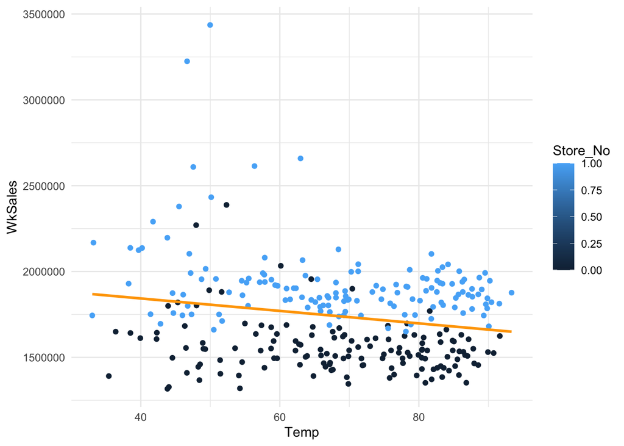

```r
#Plot of Weekly Sales vs Temperature
dataset %>% ggplot(aes(x=Temp, y=WkSales, color=Store_No)) +
  geom_point() +
  geom_smooth(method=lm, se=FALSE, formula=y~x,color="orange") +
  theme_minimal()
```

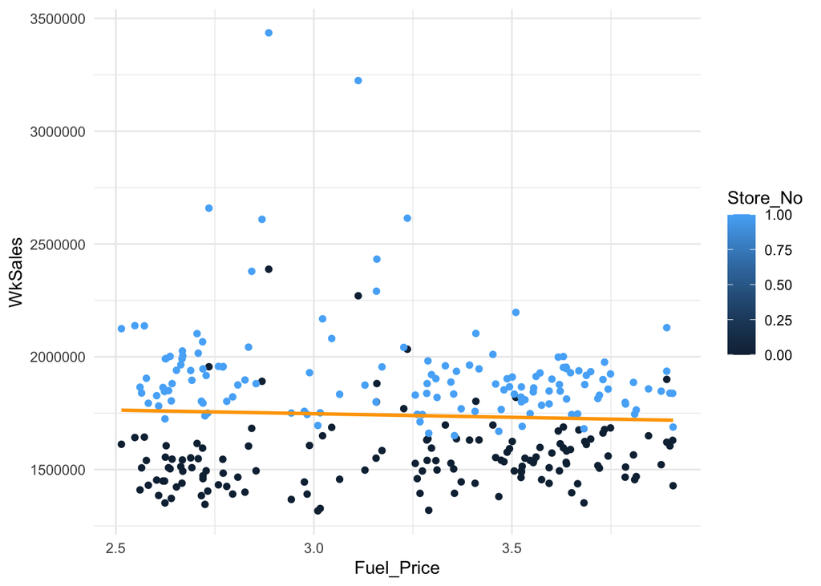

```r
#Plot of Weekly Sales vs Fuel Price
dataset %>% ggplot(aes(x=Fuel_Price, y=WkSales, color=Store_No)) +
  geom_point() +
  geom_smooth(method=lm, se=FALSE, formula=y~x,color="orange") +
  theme_minimal()
```

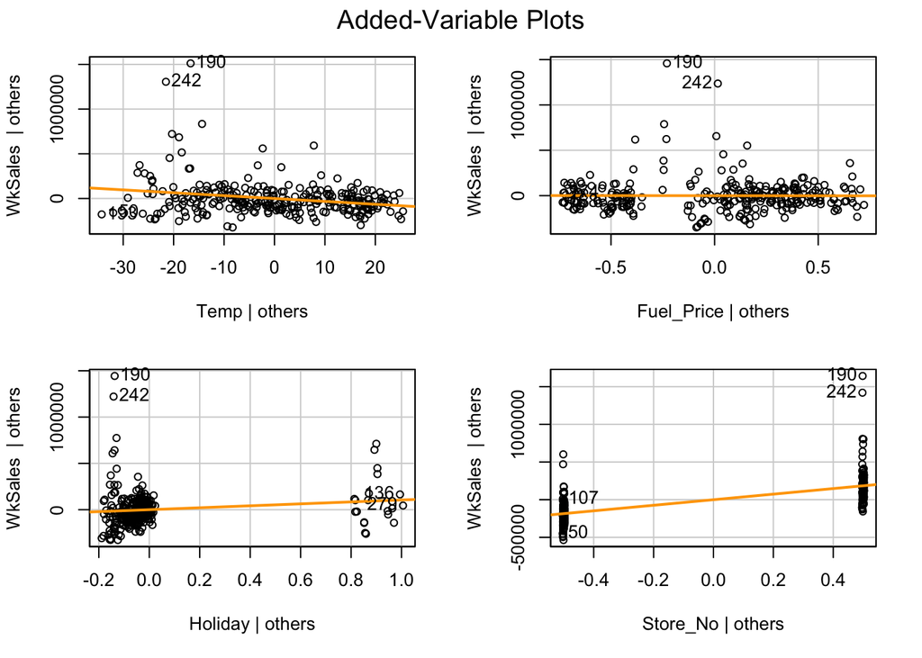

```r
#Added Variable Plot
avPlots(m2, col.lines="orange")
```

## Final Remarks

Based on the results of the final model, the Temperature, Holiday and Store Number are significant predictors of Weekly Sales. On the other hand, Fuel Price is not a significant predictor of Weekly Sales. This means that Temperature, Holiday and Store Number must be present in the model but Fuel Price could be dropped from the final model. Because we are working with multiple linear regression, it becomes a very difficult task to show a regression line on a 2-D plot when there are various predictors that are being taken into consideration for a single outcome. For this, I use an added variable plot because this plot takes the effects that one predictor can have in the outcome variable can be observed while taking into consideration other predictors in the model. The added variable plots for Temperature and Fuel Price predicting Weekly Sales make sense with the data recorded because those variables are continuous. On the other hand, the same plot but on Holiday and Store Number do not make sense because those variables are categorical and are either a 0 or a 1. Nonetheless, these plots help us visualize the data and compare it to our results. Other statistical tools could be used to help to determine how good the generated model is. In conclusion, with the numerical results and data visualization, it seems like the model generated is a good linear fit.